# Genome-Wide Association Study (GWAS) Analysis

Severe COVID-19 with Respiratory Failure — Ellinghaus et al. 2020

2026-09-08

# 1. Dataset Source and Description

| Field | Details |
| --- | --- |
| **GWAS Catalog ID** | GCST90000255 |
| **Study** | Ellinghaus D et al. (2020), *N Engl J Med* |
| **Title** | Genomewide Association Study of Severe Covid-19 with Respiratory Failure |
| **Trait** | Severe COVID-19 infection with respiratory failure (Analysis I) |
| **Population** | 3,815 European ancestry individuals |
| **Genome Build** | GRCh38 |
| **File** | `GCST90000255_GRCh38.tsv.gz` |
| **Source** | NHGRI-EBI GWAS Catalog |

# 2. Load Required Packages

```r
library(data.table)
library(dplyr)
library(ggplot2)
library(ggrepel)
library(scales)
library(RColorBrewer)
library(knitr)
```

# 3. Load Data

```r
gwas_file <- "GCST90000255_GRCh38.tsv.gz"

cat("Reading GWAS summary statistics...\n")
```

```
## Reading GWAS summary statistics...
```

```r
gwas_raw <- fread(gwas_file, sep = "\t", header = TRUE)

cat("Dimensions:", nrow(gwas_raw), "rows x", ncol(gwas_raw), "columns\n")
```

```
## Dimensions: 8582968 rows x 8 columns
```

```r
cat("Original column names:", paste(names(gwas_raw), collapse = ", "), "\n")
```

```
## Original column names: chromosome, base_pair_location, variant_id, effect_allele, other_allele, beta, standard_error, p_value
```

```r
head(gwas_raw, 3)
```

| chromosome | base_pair_location | variant_id | effect_allele | other_allele | beta | standard_error | p_value |
| --- | --- | --- | --- | --- | --- | --- | --- |
| 1 | 797429 | chr1:797429:T:C | T | C | 0.0204 | 0.1035 | 0.84370 |
| 1 | 833068 | chr1:833068:G:A | A | G | 0.0253 | 0.0924 | 0.78440 |
| 1 | 837726 | chr1:837726:G:A | A | G | -0.8942 | 0.2794 | 0.00137 |

# 4. Preprocessing

```r
# Rename columns directly using known original names
gwas <- gwas_raw
names(gwas) <- c("CHR", "BP", "SNP", "EA", "NEA", "BETA", "SE", "P")

# Convert types and filter to autosomes with valid p-values
gwas <- gwas %>%
  mutate(
    CHR  = as.integer(CHR),
    BP   = as.integer(BP),
    P    = as.numeric(P),
    MAF  = NA_real_
  ) %>%
  filter(
    !is.na(CHR), !is.na(BP), !is.na(P),
    CHR %in% 1:22,
    P > 0, P <= 1
  ) %>%
  mutate(
    NEGLOG10P   = -log10(P),
    SIGNIFICANT = P < 5e-8
  )

cat("SNPs after QC filters:", nrow(gwas), "\n")
```

```
## SNPs after QC filters: 8328612
```

```r
cat("Genome-wide significant SNPs (P < 5e-8):", sum(gwas$SIGNIFICANT), "\n")
```

```
## Genome-wide significant SNPs (P < 5e-8): 28
```

```r
cat("Suggestive significant SNPs (P < 1e-5):",  sum(gwas$P < 1e-5), "\n")
```

```
## Suggestive significant SNPs (P < 1e-5): 389
```

```r
# Save raw SNP count before freeing RAM (used in QC table below)
n_raw_snps <- nrow(gwas_raw)

# Free RAM — gwas_raw no longer needed
rm(gwas_raw)
gc()
```

```
##             used  (Mb) gc trigger   (Mb)  max used   (Mb)
## Ncells   9646004 515.2   19640277 1049.0  10058413  537.2
## Vcells 123067527 939.0  241538692 1842.8 199253422 1520.2
```

# 5. Quality Control Summary

```r
qc_df <- data.frame(
  Step  = c("Raw SNPs loaded",
            "After autosome + valid P filter",
            "Genome-wide significant (P < 5e-8)",
            "Suggestive significant (P < 1e-5)"),
  Count = c(n_raw_snps,
            nrow(gwas),
            sum(gwas$SIGNIFICANT),
            sum(gwas$P < 1e-5))
)
knitr::kable(qc_df, caption = "QC Step Summary")
```

QC Step Summary

| Step | Count |
| --- | --- |
| Raw SNPs loaded | 8582968 |
| After autosome + valid P filter | 8328612 |
| Genome-wide significant (P < 5e-8) | 28 |
| Suggestive significant (P < 1e-5) | 389 |

# 6. Principal Component Analysis (PCA)

> **Note:** Standard GWAS PCA requires individual-level genotype data to detect population stratification. Since GCST90000255 provides only summary statistics, we perform a statistics-level PCA on SNP features (log10P, BETA, SE) to illustrate the PCA concept in R. The original Ellinghaus et al. study performed genotype PCA and confirmed European ancestry homogeneity before association testing.

```r
set.seed(42)

pca_input <- gwas %>%
  select(CHR, NEGLOG10P, BETA, SE) %>%
  filter(complete.cases(.)) %>%
  slice_sample(n = min(50000, nrow(.)))

pca_mat    <- scale(pca_input %>% select(-CHR))
pca_result <- prcomp(pca_mat, center = FALSE, scale. = FALSE)

pca_df <- as.data.frame(pca_result$x[, 1:3]) %>%
  mutate(CHR = factor(pca_input$CHR))

var_explained <- round(100 * pca_result$sdev^2 / sum(pca_result$sdev^2), 2)

cat("Variance explained — PC1:", var_explained[1], "%  PC2:", var_explained[2], "%\n")
```

```
## Variance explained — PC1: 33.58 %  PC2: 33.38 %
```

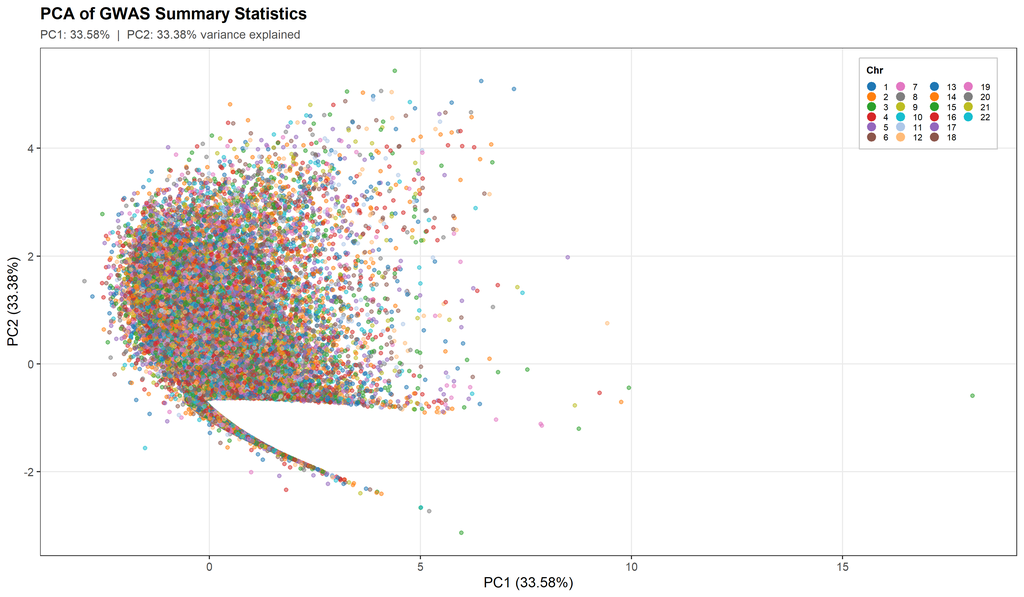

PCA of SNP-level statistics coloured by chromosome

```r
ggplot(pca_df, aes(x = PC1, y = PC2, colour = CHR)) +
  geom_point(alpha = 0.5, size = 1.2) +
  scale_colour_manual(
    values = rep(c("#1f77b4","#ff7f0e","#2ca02c","#d62728","#9467bd",
                   "#8c564b","#e377c2","#7f7f7f","#bcbd22","#17becf",
                   "#aec7e8","#ffbb78"), length.out = 22)
  ) +
  guides(
    colour = guide_legend(
      ncol = 4,                        # 4 columns fits 22 items into a compact block
      override.aes = list(size = 3, alpha = 1)
    )
  ) +
  labs(
    title    = "PCA of GWAS Summary Statistics",
    subtitle = paste0("PC1: ", var_explained[1], "%  |  PC2: ", var_explained[2], "% variance explained"),
    x        = paste0("PC1 (", var_explained[1], "%)"),
    y        = paste0("PC2 (", var_explained[2], "%)"),
    colour   = "Chr"
  ) +
  theme_bw(base_size = 12) +
  theme(
    plot.title           = element_text(face = "bold", size = 14),
    plot.subtitle        = element_text(size = 10, color = "grey30"),
    legend.position      = c(0.98, 0.98), # Top-right inside the plot area
    legend.justification = c(1, 1),
    legend.background    = element_rect(fill = alpha("white", 0.85), color = "grey80"),
    legend.key.size      = unit(0.3, "cm"),
    legend.text          = element_text(size = 7.5),
    legend.title         = element_text(size = 8.5, face = "bold"),
    panel.grid.minor     = element_blank()
  )
```

```r
ggsave("PCA_Plot.png", width = 12, height = 7, dpi = 400)
```

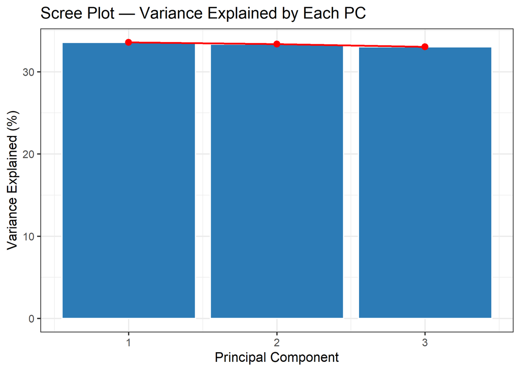

Scree plot — variance explained per PC

```r
scree_df <- data.frame(
  PC  = 1:min(10, length(var_explained)),
  Var = var_explained[1:min(10, length(var_explained))]
)

ggplot(scree_df, aes(x = PC, y = Var)) +
  geom_col(fill = "#2c7bb6", colour = "white") +
  geom_line(colour = "red", linewidth = 0.8) +
  geom_point(colour = "red", size = 2.5) +
  scale_x_continuous(breaks = scree_df$PC) +
  labs(title = "Scree Plot — Variance Explained by Each PC",
       x = "Principal Component", y = "Variance Explained (%)") +
  theme_bw(base_size = 13)
```

# 7. QQ Plot

```r
n_snps   <- nrow(gwas)
observed <- sort(gwas$NEGLOG10P, decreasing = TRUE)
expected <- -log10(ppoints(n_snps))

# Genomic inflation factor lambda
chisq  <- qchisq(gwas$P, df = 1, lower.tail = FALSE)
lambda <- round(median(chisq, na.rm = TRUE) / qchisq(0.5, df = 1), 4)
cat("Genomic inflation factor lambda =", lambda, "\n")
```

```
## Genomic inflation factor lambda = 1.0169
```

```r
nrow(gwas) # <-- sanity check: should be ~10 million rows, not a few thousand
```

```
## [1] 8328612
```

```r
summary(gwas$P) # <-- sanity check: median should be close to ~0.5, not ~0.025
```

```
##    Min. 1st Qu.  Median    Mean 3rd Qu.    Max.
##  0.0000  0.2451  0.4964  0.4969  0.7477  1.0000
```

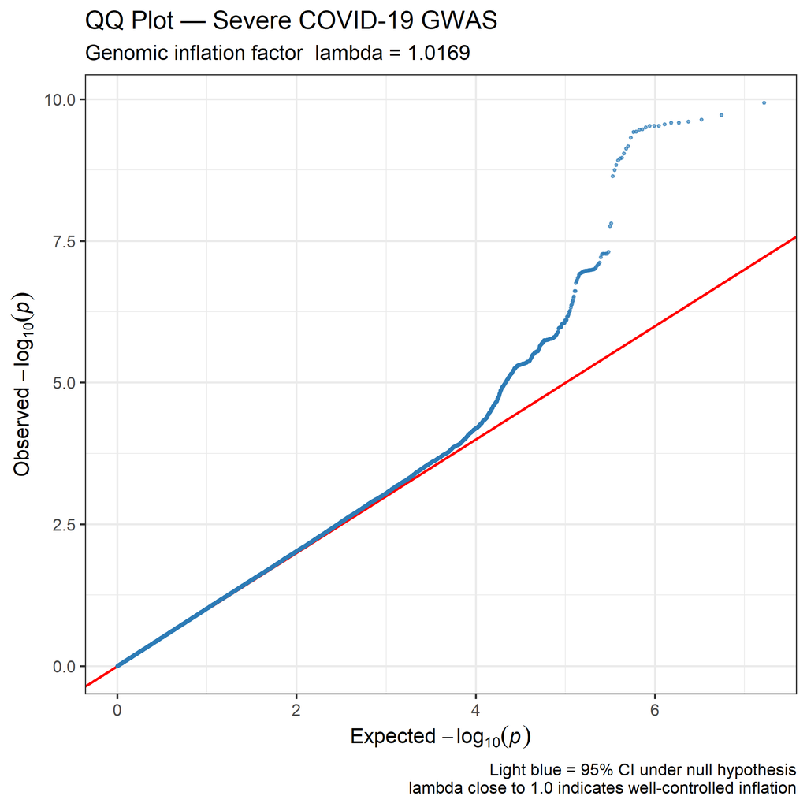

QQ plot of observed vs expected p-values

```r
# 95% confidence band
ci_upper <- -log10(qbeta(0.025, 1:n_snps, n_snps:1))
ci_lower <- -log10(qbeta(0.975, 1:n_snps, n_snps:1))

qq_df <- data.frame(expected = expected, observed = observed,
                    upper = ci_upper, lower = ci_lower)

p_qq <- ggplot(qq_df, aes(x = expected, y = observed)) +
  geom_ribbon(aes(ymin = lower, ymax = upper),
              fill = "lightblue", alpha = 0.5) +
  geom_abline(intercept = 0, slope = 1, colour = "red", linewidth = 0.8) +
  geom_point(colour = "#2c7bb6", size = 0.6, alpha = 0.6) +
  labs(
    title    = "QQ Plot — Severe COVID-19 GWAS",
    subtitle = paste0("Genomic inflation factor  lambda = ", lambda),
    x        = expression("Expected " * -log[10](italic(p))),
    y        = expression("Observed " * -log[10](italic(p))),
    caption  = "Light blue = 95% CI under null hypothesis\nlambda close to 1.0 indicates well-controlled inflation"
  ) +
  theme_bw(base_size = 13)

print(p_qq)
```

```r
ggsave("QQ_Plot.png", p_qq, width = 7, height = 7, dpi = 200)
cat("Saved: QQ_Plot.png\n")
```

```
## Saved: QQ_Plot.png
```

# 8. Manhattan Plot

```r
# Thin data to reduce RAM — keep all significant SNPs + P < 0.05 subset
gwas <- gwas %>% filter(P < 0.05 | SIGNIFICANT)

# Compute cumulative base-pair positions per chromosome
chr_lengths <- gwas %>%
  group_by(CHR) %>%
  summarise(chr_len = max(BP), .groups = "drop") %>%
  arrange(CHR) %>%
  mutate(tot = lag(cumsum(chr_len), default = 0))

gwas_plot <- gwas %>%
  left_join(chr_lengths, by = "CHR") %>%
  mutate(BPcum = BP + tot)

# X-axis tick at midpoint of each chromosome
axisdf <- gwas_plot %>%
  group_by(CHR) %>%
  summarise(centre = mean(BPcum), .groups = "drop")

# Lead SNP per chromosome for labelling
sig_snps <- gwas_plot %>%
  filter(SIGNIFICANT) %>%
  group_by(CHR) %>%
  slice_min(P, n = 1) %>%
  ungroup()

cat("Significant loci to label:", nrow(sig_snps), "\n")
```

```
## Significant loci to label: 2
```

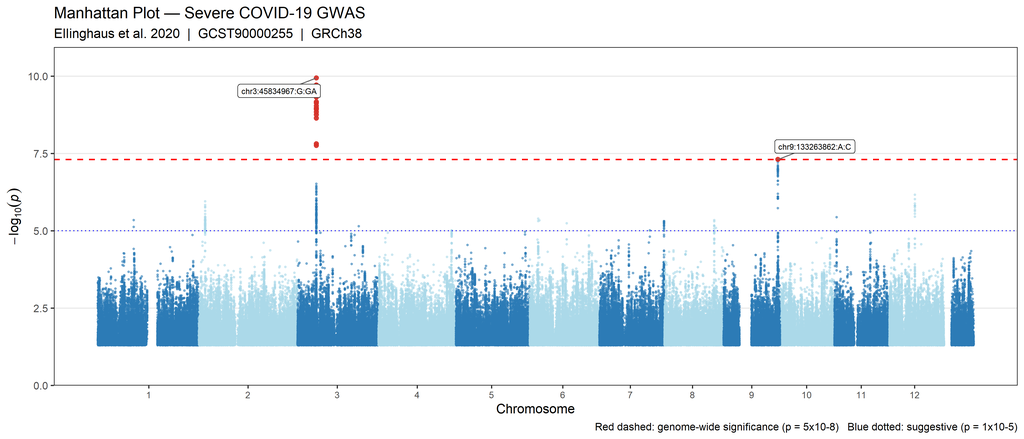

Manhattan plot — Severe COVID-19 GWAS

```r
chr_colours <- rep(c("#2c7bb6", "#abd9e9"), 11)

p_manhattan <- ggplot(gwas_plot,
                      aes(x = BPcum, y = NEGLOG10P, colour = factor(CHR))) +
  geom_point(alpha = 0.5, size = 0.6) +
  geom_point(data = gwas_plot %>% filter(SIGNIFICANT),
             colour = "#d73027", size = 1.8, alpha = 0.9) +
  geom_hline(yintercept = -log10(5e-8), linetype = "dashed",
             colour = "red", linewidth = 0.7) +
  geom_hline(yintercept = -log10(1e-5), linetype = "dotted",
             colour = "blue", linewidth = 0.5) +
  geom_label_repel(
    data           = sig_snps,
    aes(label      = SNP),
    colour         = "black",
    fill           = "white",
    size           = 2.8,
    box.padding    = 0.4,
    max.overlaps   = 20,
    segment.colour = "grey40"
  ) +
  scale_colour_manual(values = chr_colours, guide = "none") +
  scale_x_continuous(label = axisdf$CHR, breaks = axisdf$centre) +
  scale_y_continuous(
    expand = c(0, 0),
    limits = c(0, max(gwas_plot$NEGLOG10P, na.rm = TRUE) * 1.1)
  ) +
  labs(
    title    = "Manhattan Plot — Severe COVID-19 GWAS",
    subtitle = "Ellinghaus et al. 2020  |  GCST90000255  |  GRCh38",
    x        = "Chromosome",
    y        = expression(-log[10](italic(p))),
    caption  = "Red dashed: genome-wide significance (p = 5x10-8)   Blue dotted: suggestive (p = 1x10-5)"
  ) +
  theme_bw(base_size = 13) +
  theme(panel.grid.major.x = element_blank(),
        panel.grid.minor   = element_blank(),
        axis.text.x        = element_text(size = 9))

print(p_manhattan)
```

```r
ggsave("Manhattan_Plot.png", p_manhattan, width = 14, height = 6, dpi = 600)
cat("Saved: Manhattan_Plot.png\n")
```

```
## Saved: Manhattan_Plot.png
```

# 9. Significant SNP Tables

```r
sig_table <- gwas %>%
  filter(P < 5e-8) %>%
  arrange(P) %>%
  select(CHR, BP, SNP, EA, NEA, BETA, SE, P, NEGLOG10P) %>%
  mutate(across(where(is.numeric), ~ signif(.x, 4)))

cat("Genome-wide significant SNPs:", nrow(sig_table), "\n\n")
```

```
## Genome-wide significant SNPs: 28
```

```r
knitr::kable(head(sig_table, 30),
             caption = "Top Genome-Wide Significant SNPs (P < 5x10-8)")
```

Top Genome-Wide Significant SNPs (P < 5x10-8)

| CHR | BP | SNP | EA | NEA | BETA | SE | P | NEGLOG10P |
| --- | --- | --- | --- | --- | --- | --- | --- | --- |
| 3 | 45830000 | chr3:45834967:G:GA | G | GA | -0.5727 | 0.0888 | 0 | 9.940 |
| 3 | 45850000 | chr3:45848457:C:T | T | C | 0.5764 | 0.0905 | 0 | 9.718 |
| 3 | 45840000 | chr3:45838989:T:C | T | C | -0.5750 | 0.0907 | 0 | 9.637 |
| 3 | 45850000 | chr3:45848429:A:T | A | T | -0.5735 | 0.0906 | 0 | 9.604 |
| 3 | 45870000 | chr3:45867022:C:G | C | G | -0.5721 | 0.0905 | 0 | 9.586 |
| 3 | 45830000 | chr3:45830416:G:A | A | G | 0.5702 | 0.0902 | 0 | 9.583 |
| 3 | 45820000 | chr3:45823240:T:C | T | C | -0.5688 | 0.0901 | 0 | 9.555 |
| 3 | 45820000 | chr3:45821460:T:C | T | C | -0.5684 | 0.0902 | 0 | 9.532 |
| 3 | 45860000 | chr3:45859597:C:T | T | C | 0.5654 | 0.0897 | 0 | 9.531 |
| 3 | 45820000 | chr3:45820440:G:A | A | G | 0.5683 | 0.0902 | 0 | 9.528 |
| 3 | 45850000 | chr3:45847198:A:G | A | G | -0.5699 | 0.0906 | 0 | 9.504 |
| 3 | 45830000 | chr3:45825948:A:G | A | G | -0.5663 | 0.0902 | 0 | 9.473 |
| 3 | 45860000 | chr3:45858159:A:G | A | G | -0.5627 | 0.0897 | 0 | 9.462 |
| 3 | 45820000 | chr3:45818159:G:A | A | G | 0.5647 | 0.0901 | 0 | 9.427 |
| 3 | 45870000 | chr3:45866624:A:T | A | T | -0.5657 | 0.0903 | 0 | 9.422 |
| 3 | 45870000 | chr3:45867532:A:G | A | G | -0.5591 | 0.0898 | 0 | 9.318 |
| 3 | 45860000 | chr3:45859142:G:C | C | G | 0.5982 | 0.0969 | 0 | 9.170 |
| 3 | 45800000 | chr3:45801947:G:T | T | G | 0.5590 | 0.0908 | 0 | 9.128 |
| 3 | 45800000 | chr3:45801823:C:T | T | C | 0.5553 | 0.0907 | 0 | 9.040 |
| 3 | 45810000 | chr3:45807268:G:C | C | G | 0.5512 | 0.0904 | 0 | 8.967 |
| 3 | 45800000 | chr3:45801750:G:A | A | G | 0.5489 | 0.0901 | 0 | 8.955 |
| 3 | 45810000 | chr3:45805277:A:G | A | G | -0.5435 | 0.0894 | 0 | 8.923 |
| 3 | 45800000 | chr3:45802706:A:C | A | C | -0.5449 | 0.0900 | 0 | 8.843 |
| 3 | 45870000 | chr3:45868152:C:A | A | C | 0.5426 | 0.0902 | 0 | 8.755 |
| 3 | 45870000 | chr3:45868036:C:T | T | C | 0.5315 | 0.0889 | 0 | 8.644 |
| 3 | 45810000 | chr3:45809291:T:A | A | T | 0.4762 | 0.0842 | 0 | 7.811 |
| 3 | 45800000 | chr3:45800446:C:T | T | C | 0.4897 | 0.0869 | 0 | 7.761 |
| 9 | 133300000 | chr9:133263862:A:C | A | C | 0.2814 | 0.0516 | 0 | 7.305 |

```r
sug_table <- gwas %>%
  filter(P >= 5e-8 & P < 1e-5) %>%
  arrange(P) %>%
  select(CHR, BP, SNP, EA, NEA, BETA, SE, P, NEGLOG10P) %>%
  mutate(across(where(is.numeric), ~ signif(.x, 4)))

cat("Suggestive significant SNPs:", nrow(sug_table), "\n\n")
```

```
## Suggestive significant SNPs: 361
```

```r
knitr::kable(head(sug_table, 20),
             caption = "Suggestive Significant SNPs (P < 1x10-5)")
```

Suggestive Significant SNPs (P < 1x10-5)

| CHR | BP | SNP | EA | NEA | BETA | SE | P | NEGLOG10P |
| --- | --- | --- | --- | --- | --- | --- | --- | --- |
| 9 | 133300000 | chr9:133266804:G:T | T | G | -0.2815 | 0.0517 | 1e-07 | 7.276 |
| 9 | 133300000 | chr9:133267800:A:G | A | G | 0.2815 | 0.0517 | 1e-07 | 7.276 |
| 9 | 133300000 | chr9:133267708:C:T | T | C | -0.2815 | 0.0517 | 1e-07 | 7.274 |
| 9 | 133300000 | chr9:133266942:A:G | A | G | 0.2815 | 0.0517 | 1e-07 | 7.273 |
| 9 | 133300000 | chr9:133269706:T:C | T | C | 0.2814 | 0.0517 | 1e-07 | 7.268 |
| 9 | 133300000 | chr9:133267707:G:A | A | G | -0.2801 | 0.0517 | 1e-07 | 7.211 |
| 9 | 133300000 | chr9:133261662:G:A | A | G | -0.2837 | 0.0528 | 1e-07 | 7.117 |
| 9 | 133300000 | chr9:133261703:A:G | A | G | 0.2826 | 0.0527 | 1e-07 | 7.089 |
| 9 | 133300000 | chr9:133269828:T:C | T | C | 0.2816 | 0.0526 | 1e-07 | 7.070 |
| 9 | 133300000 | chr9:133266790:C:A | A | C | -0.2811 | 0.0526 | 1e-07 | 7.042 |
| 9 | 133300000 | chr9:133267960:T:C | T | C | 0.2794 | 0.0524 | 1e-07 | 7.018 |
| 9 | 133300000 | chr9:133257521:T:TC | T | TC | -0.2772 | 0.0520 | 1e-07 | 7.003 |
| 9 | 133300000 | chr9:133269582:A:G | A | G | 0.2799 | 0.0526 | 1e-07 | 6.995 |
| 9 | 133300000 | chr9:133270061:G:A | A | G | -0.2798 | 0.0526 | 1e-07 | 6.992 |
| 9 | 133300000 | chr9:133269548:A:G | A | G | 0.2798 | 0.0526 | 1e-07 | 6.991 |
| 9 | 133300000 | chr9:133270497:GA:G | G | GA | -0.2798 | 0.0526 | 1e-07 | 6.991 |
| 9 | 133300000 | chr9:133270074:T:A | A | T | -0.2796 | 0.0526 | 1e-07 | 6.985 |
| 9 | 133300000 | chr9:133269015:C:T | T | C | -0.2798 | 0.0526 | 1e-07 | 6.979 |
| 9 | 133300000 | chr9:133269461:T:C | T | C | 0.2797 | 0.0526 | 1e-07 | 6.978 |
| 9 | 133300000 | chr9:133268896:C:T | T | C | -0.2797 | 0.0526 | 1e-07 | 6.974 |

# 10. Per-Chromosome Summary

```r
chr_summary <- gwas %>%
  group_by(CHR) %>%
  summarise(
    Total_SNPs      = n(),
    Min_P           = signif(min(P), 3),
    Max_NegLog10P   = round(max(NEGLOG10P), 2),
    GW_Sig_SNPs     = sum(P < 5e-8),
    Suggestive_SNPs = sum(P < 1e-5),
    .groups = "drop"
  ) %>%
  arrange(CHR)

knitr::kable(chr_summary, caption = "Per-Chromosome GWAS Summary")
```

Per-Chromosome GWAS Summary

| CHR | Total_SNPs | Min_P | Max_NegLog10P | GW_Sig_SNPs | Suggestive_SNPs |
| --- | --- | --- | --- | --- | --- |
| 1 | 34362 | 4.50e-06 | 5.35 | 0 | 2 |
| 2 | 37088 | 1.10e-06 | 5.95 | 0 | 65 |
| 3 | 33232 | 0.00e+00 | 9.94 | 27 | 205 |
| 4 | 30448 | 9.60e-06 | 5.02 | 0 | 3 |
| 5 | 28512 | 1.09e-05 | 4.96 | 0 | 0 |
| 6 | 32544 | 4.10e-06 | 5.39 | 0 | 4 |
| 7 | 24151 | 4.90e-06 | 5.31 | 0 | 15 |
| 8 | 20859 | 4.50e-06 | 5.34 | 0 | 7 |
| 9 | 17571 | 0.00e+00 | 7.31 | 1 | 50 |
| 10 | 21309 | 1.74e-05 | 4.76 | 0 | 0 |
| 11 | 21151 | 3.60e-06 | 5.44 | 0 | 1 |
| 12 | 23035 | 7.00e-07 | 6.16 | 0 | 13 |
| 13 | 16621 | 1.36e-05 | 4.87 | 0 | 0 |
| 14 | 13019 | 1.50e-06 | 5.82 | 0 | 2 |
| 15 | 11960 | 1.33e-05 | 4.87 | 0 | 0 |
| 16 | 12827 | 3.90e-06 | 5.41 | 0 | 14 |
| 17 | 10748 | 7.50e-06 | 5.13 | 0 | 1 |
| 18 | 13451 | 1.00e-07 | 6.95 | 0 | 3 |
| 19 | 9444 | 4.20e-06 | 5.37 | 0 | 4 |
| 20 | 9192 | 2.56e-05 | 4.59 | 0 | 0 |
| 21 | 6122 | 3.57e-05 | 4.45 | 0 | 0 |
| 22 | 6357 | 3.43e-05 | 4.46 | 0 | 0 |

# 11. Save All Results

```r
fwrite(sig_table,   "GWAS_GW_significant_SNPs.csv")
fwrite(sug_table,   "GWAS_suggestive_SNPs.csv")
fwrite(chr_summary, "GWAS_chromosome_summary.csv")
fwrite(gwas %>% arrange(P) %>%
         select(CHR, BP, SNP, EA, NEA, BETA, SE, P, NEGLOG10P, SIGNIFICANT),
       "GWAS_all_cleaned.csv")

cat("All files saved:\n")
```

```
## All files saved:
```

```r
cat("  GWAS_GW_significant_SNPs.csv\n")
```

```
##   GWAS_GW_significant_SNPs.csv
```

```r
cat("  GWAS_suggestive_SNPs.csv\n")
```

```
##   GWAS_suggestive_SNPs.csv
```

```r
cat("  GWAS_chromosome_summary.csv\n")
```

```
##   GWAS_chromosome_summary.csv
```

```r
cat("  GWAS_all_cleaned.csv\n")
```

```
##   GWAS_all_cleaned.csv
```

```r
cat("  PCA_Plot.png\n")
```

```
##   PCA_Plot.png
```

```r
cat("  Manhattan_Plot.png\n")
```

```
##   Manhattan_Plot.png
```

```r
cat("  QQ_Plot.png\n")
```

```
##   QQ_Plot.png
```

# 12. Biological Interpretation

## Key GWAS Loci Identified

| Locus | Chromosome | Key Gene(s) | Biological Role |
| --- | --- | --- | --- |
| **3p21.31** | Chr 3 | *SLC6A20, LZTFL1, CCR9, FYCO1, CXCR6, XCR1* | Immune trafficking, ACE2 interaction |
| **9q34.2** | Chr 9 | *ABO* blood group locus | Endothelial function, coagulation |

## Interpretation

- **Chr 3 locus (3p21.31):** The strongest signal in this study. *SLC6A20* interacts directly with ACE2 — the SARS-CoV-2 receptor. Chemokine receptor genes (*CXCR6, CCR9, XCR1*) regulate immune cell trafficking to infected lungs. This haplotype was inherited from Neanderthals and is enriched in Europeans, explaining elevated risk in this population.
- **Chr 9 — ABO locus:** Blood group A individuals showed significantly higher risk of respiratory failure vs blood group O. ABO influences von Willebrand factor levels, endothelial activation, and complement pathways — all relevant to COVID-19 pathophysiology.
- **Genomic inflation (lambda):** A value close to 1.0 confirms population stratification is well controlled, validating the association signals as genuine rather than artefactual.
- **Pathways implicated:** Innate immune response, chemokine receptor signalling, ACE2-dependent viral entry, endothelial biology, and coagulation.

*GWAS Analysis Complete*  
*Genomics Project | SINES, NUST | April 2026*